# How to work with audio projects in Kili

Kili audio projects are designed for **speech transcription with speaker attribution**: a labeler listens to a recording, draws *segments* on the waveform, types what is being said in each of them, and assigns each segment to a *speaker*.

In this tutorial, we will go through the full life cycle of an audio project:

1. Setting up an audio project
2. Importing audio assets
3. Understanding the audio label format
4. Importing model pre-annotations (predictions)
5. Exporting audio labels
6. Cleanup

Let's start by installing the SDK and instantiating the client. `Kili()` reads your API key from the `KILI_API_KEY` environment variable — see [how to create one](https://docs.kili-technology.com/docs/creating-an-api-key).

```
%pip install  kili
```

```
import json

from kili.client import Kili

kili = Kili()
```

## 1. Setting up an audio project

### Designing the labeling interface

An audio interface is made of two kinds of jobs, and it is worth understanding the distinction before writing any code.

**Segment-level jobs.** A `TRANSCRIPTION` job that is *not* flagged as asset-level is the transcription job of the project. It is the job that materializes the segments drawn on the waveform: every segment is one annotation of that job, with a time interval, a piece of text and a speaker. An audio project has **exactly one** such job — it is what makes the waveform editable.

A `CLASSIFICATION` job that is *not* flagged as asset-level is segment-level too: it is answered **once per segment**, for instance with the emotion of the speaker. Its categories take no nested job.

**Asset-level jobs.** Any job carrying `"level": "asset"` applies to the *whole recording* rather than to a segment. They are rendered in a side panel on the right of the interface and behave like the classification and transcription jobs you already know from image or text projects. Use them for metadata such as the language of the call, the audio quality, or a free-text summary.

Let's build an interface with one transcription job, one segment-level classification job and two asset-level classification jobs.

```
json_interface = {
    "jobs": {
        # Segment-level job: this is the job the waveform segments belong to.
        # A TRANSCRIPTION job without "level": "asset" is the transcription job of the project.
        "TRANSCRIPTION_JOB": {
            "mlTask": "TRANSCRIPTION",
            "content": {"input": "textField"},
            "instruction": "Transcription",
            "required": 0,
            "isChild": False,
        },
        # Segment-level classification: a CLASSIFICATION job without "level": "asset" is answered
        # once per segment.
        "EMOTION_JOB": {
            "mlTask": "CLASSIFICATION",
            "content": {
                "categories": {
                    "NEUTRAL": {"children": [], "name": "Neutral", "id": "category_neutral"},
                    "POSITIVE": {"children": [], "name": "Positive", "id": "category_positive"},
                    "NEGATIVE": {"children": [], "name": "Negative", "id": "category_negative"},
                },
                "input": "radio",
            },
            "instruction": "Emotion of the speaker",
            "required": 0,
            "isChild": False,
        },
        # Asset-level job: applies to the whole recording, shown in the right-hand panel.
        "LANGUAGE_JOB": {
            "mlTask": "CLASSIFICATION",
            "content": {
                "categories": {
                    "ENGLISH": {"children": [], "name": "English", "id": "category_english"},
                    "FRENCH": {"children": [], "name": "French", "id": "category_french"},
                    "OTHER": {"children": [], "name": "Other", "id": "category_other"},
                },
                "input": "singleDropdown",
            },
            "instruction": "Language of the recording",
            "required": 1,
            "isChild": False,
            "level": "asset",
        },
        "AUDIO_CHARACTERISTICS_JOB": {
            "mlTask": "CLASSIFICATION",
            "content": {
                "categories": {
                    "BACKGROUND_MUSIC": {
                        "children": [],
                        "name": "Background music",
                        "id": "category_music",
                    },
                    "BACKGROUND_NOISE": {
                        "children": [],
                        "name": "Background noise",
                        "id": "category_noise",
                    },
                    "MULTIPLE_SPEAKERS": {
                        "children": [],
                        "name": "Multiple speakers",
                        "id": "category_multi",
                    },
                },
                "input": "checkbox",
            },
            "instruction": "Audio characteristics",
            "required": 0,
            "isChild": False,
            "level": "asset",
        },
    }
}
```

In the project settings, Kili labels each job with the level it applies to, so you can check at a glance that your interface is what you intended:

[figure not shown]

### Creating the project

Audio projects use the `AUDIO` input type.

```
project = kili.create_project(
    title="[Kili SDK Notebook]: Audio transcription",
    description="Speaker-attributed transcription of customer support calls",
    input_type="AUDIO",
    json_interface=json_interface,
)

project_id = project["id"]
print("Project ID:", project_id)
```

```
Project ID: cmsws1pir04wkvm0w0nh8fqc9
```

## 2. Importing audio assets

Audio assets are imported like any other asset type, with `append_many_to_dataset`.

Kili accepts **`.mp3`, `.wav`, `.flac` and `.mp4`** files.

### From a URL

```
AUDIO_URL = "https://storage.googleapis.com/label-public-staging/demo-projects/audio/EN_Support.mp3"

kili.append_many_to_dataset(
    project_id=project_id,
    content_array=[AUDIO_URL],
    external_id_array=["support_call_en"],
)
```

### From a local file

To upload a file that sits on your machine, pass its path instead of a URL. Note that hosted files and local files cannot be mixed in a single call — use one call for each.

```
import urllib.request

urllib.request.urlretrieve(AUDIO_URL, "support_call.mp3")

kili.append_many_to_dataset(
    project_id=project_id,
    content_array=["./support_call.mp3"],
    external_id_array=["support_call_en_local"],
)
```

## 3. Understanding the audio label format

An audio `jsonResponse` has one key that no other input type has: `speakers`.

```
{
  "speakers": [
    {"id": "spk_agent", "name": "Agent", "color": "#7C3AED"},
    {"id": "spk_customer", "name": "Customer", "color": "#059669"}
  ],
  "TRANSCRIPTION_JOB": {
    "annotations": [
      {
        "mid": "segment_000",
        "startTime": 2.0,
        "endTime": 2.3,
        "speakerId": "spk_customer",
        "text": "Hello.",
        "children": {"EMOTION_JOB": {"categories": [{"name": "NEUTRAL"}]}}
      }
    ]
  },
  "LANGUAGE_JOB": {"categories": [{"name": "ENGLISH"}]},
  "AUDIO_CHARACTERISTICS_JOB": {"categories": [{"name": "MULTIPLE_SPEAKERS"}]}
}
```

### Speakers

`speakers` is the cast of the recording. Speakers are defined **per label**, not per project: two assets in the same project can have completely different speakers, which is exactly what you want when each recording is a different conversation.

| Field | Type | Description |
| --- | --- | --- |
| `id` | `str` | The identifier you choose. Segments reference the speaker through it. |
| `name` | `str` | The name displayed on the speaker tag, e.g. `Agent`. |
| `color` | `str` | Hex color of the tag and of the segment on the waveform, e.g. `#7C3AED`. |

All three fields are required. Colors are free-form hex strings; the palette the Kili interface uses when a labeler adds a speaker by hand is `#7C3AED`, `#2563EB`, `#059669`, `#DC2626`, `#D97706`, `#0891B2`, `#EC4899`, `#4F46E5`, and picking from it keeps imported labels visually consistent with manually created ones.

### Segments

The transcription job holds an `annotations` list — one entry per segment on the waveform.

| Field | Type | Required | Description |
| --- | --- | --- | --- |
| `mid` | `str` | yes | Identifier of the segment, unique within the label. It is preserved on export, which makes it the reliable key to join a segment back to your own data. |
| `startTime` | `float` | yes | Start of the segment, **in seconds**. |
| `endTime` | `float` | yes | End of the segment, **in seconds**. |
| `text` | `str` | yes | The transcription. Use `""` for a segment that still has to be transcribed. |
| `speakerId` | `str` | no | Id of one of the entries of `speakers`. Omit it (or set it to `null`) to leave the segment unassigned — it will show up as *Unknown* in the interface. |
| `children` | `dict` | no | The segment's answers to the segment-level classification jobs, keyed by job name: `{"EMOTION_JOB": {"categories": [{"name": "NEUTRAL"}]}}`. Omit it for a segment that answers none. |

Times are expressed in seconds as floats, with millisecond precision — Kili stores them internally as integer milliseconds, so `2.3456` is rounded to `2.346`.

### Asset-level jobs

Asset-level jobs use the classic `jsonResponse` shape you already know, keyed by job name: `{"categories": [{"name": "ENGLISH"}]}` for a classification, `{"text": "..."}` for a transcription.

## 4. Importing model pre-annotations

Speech-to-text models paired with a diarization model produce exactly the information Kili needs: time-aligned segments, their transcription, and which speaker uttered them. Importing them as **predictions** gives labelers a draft to correct instead of a blank waveform.

Here we hardcode the output of such a pipeline, but in a real workflow this would come from Whisper, `pyannote.audio`, a cloud speech API, or your own model.

```
speakers = [
    {"id": "spk_agent", "name": "Agent", "color": "#7C3AED"},
    {"id": "spk_customer", "name": "Customer", "color": "#059669"},
]

# (start, end, speaker, text, emotion) as produced by a transcription + diarization pipeline,
# with an emotion model on top; None where the model gave no emotion
raw_segments = [
    (2.00, 2.30, "spk_customer", "Hello.", "NEUTRAL"),
    (3.90, 5.40, "spk_agent", "Hello, I'm speaking to Mariam.", "NEUTRAL"),
    (6.40, 7.50, "spk_customer", "Yes, speaking.", "NEUTRAL"),
    (8.20, 9.40, "spk_agent", "Hello, my name is Stephen.", "POSITIVE"),
    (9.50, 13.30, "spk_agent", "I'm calling you from the finance department.", None),
    (
        14.20,
        18.10,
        "spk_agent",
        "You were speaking with Michael before, and your manager is Mr. Omar, correct?",
        None,
    ),
    (19.10, 20.10, "spk_customer", "Okay.", "NEUTRAL"),
    (
        20.10,
        31.40,
        "spk_agent",
        "All right. I was calling you because we were trying to find a way to make a quick and easy withdrawal of your money back to your bank.",
        None,
    ),
    (
        31.70,
        36.30,
        "spk_agent",
        "I think we finally found an option, and that's why I'm calling you.",
        "POSITIVE",
    ),
    (36.80, 39.70, "spk_agent", "It will just take another five or ten minutes.", None),
    (
        40.00,
        44.50,
        "spk_agent",
        "If you're available, I would like to guide you through the steps.",
        None,
    ),
    (48.30, 50.40, "spk_agent", "So are you available for me to help you with that?", None),
    (51.90, 52.30, "spk_customer", "Yes.", "POSITIVE"),
    (53.00, 54.10, "spk_agent", "Okay, wonderful.", "POSITIVE"),
]

json_response = {
    "speakers": speakers,
    "TRANSCRIPTION_JOB": {
        "annotations": [
            {
                "mid": f"segment_{index:03d}",
                "startTime": start,
                "endTime": end,
                "speakerId": speaker_id,
                "text": text,
                # segment-level classification: a segment carries its answers under "children"
                **(
                    {"children": {"EMOTION_JOB": {"categories": [{"name": emotion}]}}}
                    if emotion
                    else {}
                ),
            }
            for index, (start, end, speaker_id, text, emotion) in enumerate(raw_segments)
        ]
    },
    # asset-level jobs, filled in the same call
    "LANGUAGE_JOB": {"categories": [{"name": "ENGLISH"}]},
    "AUDIO_CHARACTERISTICS_JOB": {"categories": [{"name": "MULTIPLE_SPEAKERS"}]},
}
```

`label_type="PREDICTION"` marks the label as model output, and `model_name` records which model produced it, so you can later compare several models on the same assets.

```
kili.append_labels(
    project_id=project_id,
    asset_external_id_array=["support_call_en"],
    json_response_array=[json_response],
    label_type="PREDICTION",
    model_name="whisper-large-v3",
)
```

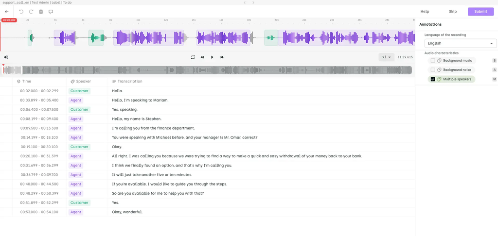

A few things to keep in mind when building the `jsonResponse`:

- **`mid` is mandatory.** Unlike bounding boxes in image projects, audio segments are not assigned an identifier automatically; a segment without a `mid` is rejected.
- **Segments do not have to be sorted.** Kili orders them by `startTime` when it returns them.
- **Overlapping segments are allowed**, which matters when two people talk over each other.
- **Every `speakerId` should exist in `speakers`.** A segment pointing at an unknown speaker is imported, but the interface will render it as *Unknown*.
- **`children` only takes segment-level classification jobs.** A job or a category the interface does not define is refused, and so is a segment-level job answered at the root of the `jsonResponse`.

To import ground-truth labels rather than predictions, use the very same `jsonResponse` with the default `label_type="DEFAULT"`.

## 5. Exporting audio labels

`kili.labels` returns the labels of a project. Beyond `jsonResponse`, audio labels expose the `speakers` relation, which gives you the cast of each label.

```
labels = kili.labels(
    project_id=project_id,
    asset_external_id_in=["support_call_en"],
    fields=[
        "labelType",
        "modelName",
        "jsonResponse",
        "speakers.id",
        "speakers.name",
        "speakers.color",
    ],
)

label = labels[0]
print(label["labelType"], "-", label["modelName"])
print(json.dumps(label["speakers"], indent=2))
```

```
PREDICTION - whisper-large-v3
[
  {
    "id": "spk_agent",
    "name": "Agent",
    "color": "#7C3AED"
  },
  {
    "id": "spk_customer",
    "name": "Customer",
    "color": "#059669"
  }
]
```

```
segments = label["jsonResponse"]["TRANSCRIPTION_JOB"]["annotations"]

print(f"{len(segments)} segments")
print(json.dumps(segments[:2], indent=2))
```

[output not shown]

Labels can also be read as objects rather than as raw dictionaries, with `output_format="parsed_label"`: each segment then exposes its transcription, its times, its speaker and its classifications.

[output not shown]

### Exporting the whole project to a file

To get every asset and every label at once, use `export_labels`. The `raw` and `kili` formats keep the audio `jsonResponse` untouched, `speakers` relation aside; the computer-vision formats (`coco`, `yolo_*`, `pascal_voc`) and `geojson` do not apply to audio.

By default only submitted labels are exported, so pass `label_type_in` and `export_type="normal"` if you also want the predictions.

```
kili.export_labels(
    project_id=project_id,
    filename="audio_export.zip",
    fmt="raw",
    with_assets=False,
    label_type_in=["DEFAULT", "PREDICTION"],
    export_type="normal",
)
```

## 6. Cleanup

Let's remove the project we created for this tutorial.

```
kili.delete_project(project_id)
```

## Summary

We created an audio project, learned the difference between the segment-level jobs and the asset-level jobs, imported audio assets from a URL and from disk, imported speaker-attributed predictions, and exported them back.

For more on the concepts used along the way, see:

- [Importing assets](https://python-sdk-docs.kili-technology.com/latest/sdk/tutorials/importing_assets_and_metadata/)
- [Importing labels](https://python-sdk-docs.kili-technology.com/latest/sdk/tutorials/importing_labels/)
- [Exporting a project](https://python-sdk-docs.kili-technology.com/latest/sdk/tutorials/export_a_kili_project/)